### Question 1

Relational databases are based on which mathematical theory or field?

Information theory  
Matrix algebra  
Set theory  
Probability theory

### Question 2

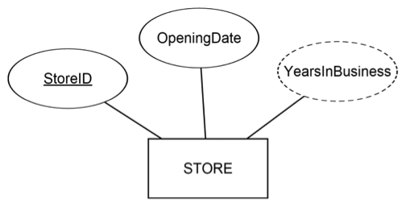

YearsInBusiness in the ER diagram above is a:

Composite attribute  
Unique attribute  
Candidate key  
Derived attribute

### Question 3

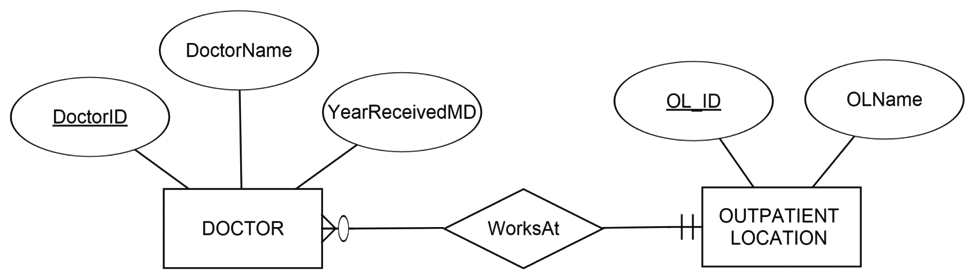

Which of the following is true about cardinality constraints on the relationship between Doctor and Outpatient Location depicted in this ER diagram?

An outpatient location must have 1 doctor working at it, but can have no more than 1 doctor working at it.  
A doctor can work at many outpatient locations, but does not have to work at any.  
An outpatient location must have at least 1 doctor working at it, but can have many doctors working at it.  
A doctor is required to work at one outpatient location, but can work at no more than 1 outpatient location.

### Question 4

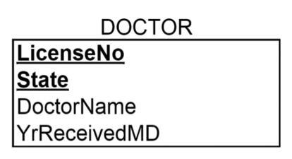

Which columns would be necessary for identifying unique doctors in the doctor table of the database built from the relational schema excerpt above?

You could use either LicenseNo or State  
LicenseNo  
You would have to use both LicenseNo and State  
State

### Question 5

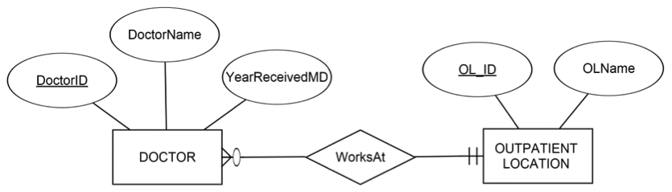

In the ER diagram above, Doctor_ID and OL_ID are called:

Primary keys  
Composite attributes or keys  
Unique attributes  
Foreign keys

### Question 6

Which type of information is most likely to be stored in a relational database as opposed to another type of database?

Metadata (file name, file location, when the file was created, etc.) about pictures  
Tweets  
Pictures  
Texts

### Question 7

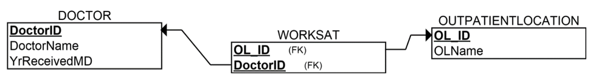

What can you infer about the data being collected based on the relational schema above?

A doctor can only work at one outpatient location, but an outpatient location can have many doctors working at it  
The data collected in OL_ID of the OutpatientLocation table, on its own, is sufficient to determine at which outpatient location(s) each doctor works  
The data collected in OL_ID of the WorksAt table, on its own, is sufficient to determine at which outpatient location(s) each doctor works  
A doctor can work at many outpatient locations, and an outpatient location can have many doctors working at it

### Question 8

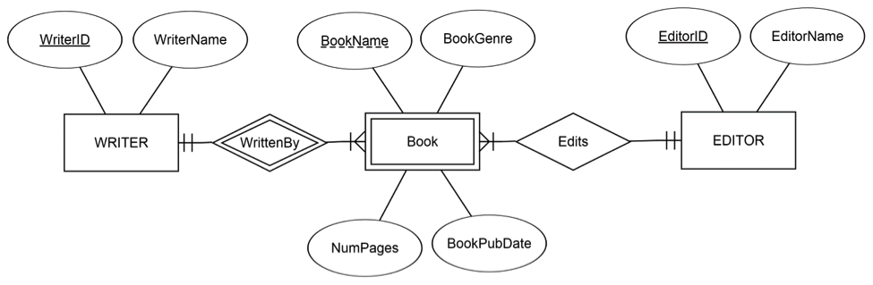

Based on the diagram above, which attribute(s) can be used to identify unique books?

BookName and EditorID  
BookName and WriterID  
BookName and BookPubDate  
BookName

### Question 9

Which of the following statements are true about foreign keys? Check all that apply. (Note that you will need to select more than one correct response to answer this question correctly.)

Foreign keys allow information in different tables to be linked to each other  
Foreign keys are columns with unique values for every row in the relation/table they are in  
Foreign keys refer to columns with unique values for every row in other relations/tables  
Foreign keys always have the same name as at least one primary key in another table

### Question 10

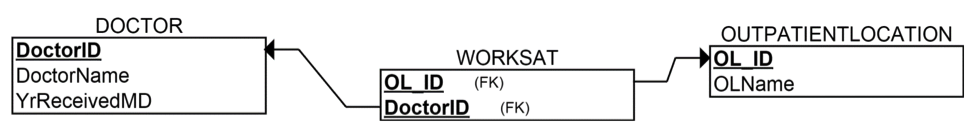

Given the relational schema presented above, how many tables would you need to use in order to determine the outpatient location(s) a doctor named "Karen Smith" works at?

1  
2 or 3, depending on the strategy you use to combine the information  
2  
3

### Question 11

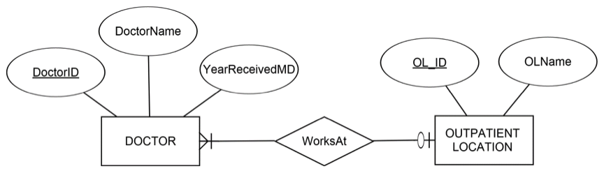

Which of the following is true about cardinality constraints on the relationship between Doctor and Outpatient Location depicted in this ER diagram?

A doctor can work at many outpatient locations, but does not have to work at any.  
A doctor is required to work at one outpatient location, but can work at no more than 1 outpatient location.  
An outpatient location must have at least 1 doctor working at it, but can have many doctors working at it.  
Each outpatient location must have 1 doctor working at it, but can have no more than 1 doctor working at it.

### Question 12

Which of the following statements are true about **t** **he technical terms** (as opposed to the common terms) for the concepts represented by relational schemas?

The technical term for items in a relational schema that become rows in a real database is “tuples.”  
The technical term for items in a relational schema that become columns in a real database is “fields”  
The technical term for items in a relational schema that become tables in a real database is “entities”

### Question 13

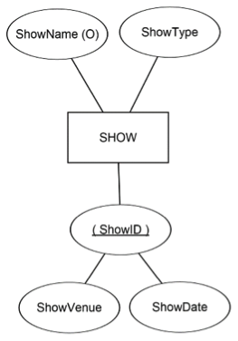

Based on the diagram above, which of the following is true?

ShowDate and ShowVenue are needed together to provide a unique identifier for each show  
ShowID and ShowVenue are needed together to provide a unique identifier for each show  
ShowType and ShowName are needed together to provide a unique identifier for each show  
ShowType and ShowVenue are needed together to provide a unique identifier for each show

### Question 14

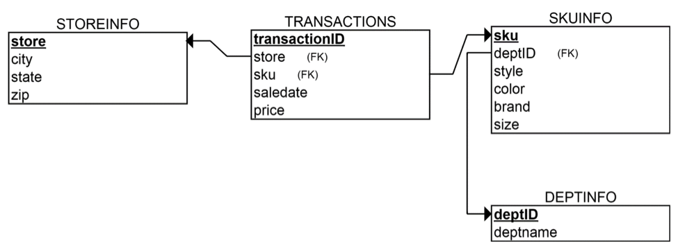

If this relational schema represented a database that was already implemented, what columns would you use to combine the information in the transactions table with the information in the departinfo table?

“deptname” to connect the transactions table to the deptinfo table  
“store” to connect the transactions table to the storeinfo table, and then “deptname” to connect the storeinfo table to the deptinfo table  
“sku” to connect the transactions table to the skuinfo table, and then “deptname” to connect the skuinfo table to the deptinfo table  
sku” to connect the transactions table to the skuinfo table, and then “deptID” to connect the skuinfo table to the deptinfo table

### Question 15

For relational databases to work most efficiently, which of the following requirements of set theory should be followed? Check all that apply. (Note that you will need to select more than one correct response to answer this question correctly.)

Each row in a table should represent a unique instance of the information in that table  
Each column in a table should represent a unique category of information  
Single tables should represent the smallest logical parts of a data set  
There should be no NULL values allowed in the database